# Simple Regression Model for Predicting Abalone Age Using R

David Lowe

March 23, 2018

Template Credit: Adapted from template made available by Dr. Jason Brownlee of Machine Learning Mastery (http://machinelearningmastery.com/)

For more information on this case study project, please consult Dr. Brownlee’s blog post at https://machinelearningmastery.com/standard-machine-learning-datasets/.

Dataset Used: Abalone Data Set Data Set ML Model: Regression with Categorical, Integer, Real attributes Dataset Reference: http://archive.ics.uci.edu/ml/datasets/Abalone

The Abalone Dataset involves predicting the age of abalone given objective measures of individuals. Although it was presented as a multi-class classification problem, this exercise will frame it using regression. The baseline performance of predicting the mean value is an RMSE of approximately 3.2 rings.

The purpose of this project is to analyze a dataset using various machine learning algorithms and to document the steps using a template. The project aims to touch on the following areas:

1. Document a regression predictive modeling problem end-to-end.
2. Explore data transformation options for improving model performance
3. Explore algorithm tuning techniques for improving model performance
4. Explore using and tuning ensemble methods for improving model performance

Working through machine learning problems from end-to-end requires a structured modeling approach. Working problems through a project template can encourage you to think about the problem more critically, to challenge your assumptions, and to get good at all parts of a modeling project.

Any predictive modeling machine learning project can be broken down into about 6 common tasks:

1. Define Problem
2. Summarize Data
3. Prepare Data
4. Evaluate Algorithms
5. Improve Accuracy or Results
6. Finalize Model and Present Results

We will compare several different algorithms and determine which one would yield the best results.

## 1. Prepare Problem

### 1.a) Load libraries

```r
library(AppliedPredictiveModeling)
library(caret)
```

```r
library(corrplot)
```

### 1.b) Load dataset

```r
data(abalone)
dataset <- abalone
```

### 1.c) Split-out validation dataset

Normally, we would create a training (variable name “dataset”) and a validation (variable name “validation”) dataset. Because this dataset is relatively small, we will opt to test the algorithms with the full set of data and not splitting.

```r
# Not applicable for this iteration of the project.
```

## 2. Summarize Data

To gain a better understanding of the data that we have on-hand, we will leverage a number of descriptive statistics and data visualization techniques. The plan is to use the results to consider new questions, review assumptions, and validate hypotheses that we can investigate later with specialized models.

### 2.a) Descriptive statistics

#### 2.a.i) Dimensions of the dataset.

```r
dim(dataset)
```

```
## [1] 4177    9
```

#### 2.a.ii) Types of the attributes.

```r
sapply(dataset, class)
```

```
##          Type  LongestShell      Diameter        Height   WholeWeight
##      "factor"     "numeric"     "numeric"     "numeric"     "numeric"
## ShuckedWeight VisceraWeight   ShellWeight         Rings
##     "numeric"     "numeric"     "numeric"     "integer"
```

#### 2.a.iii) Peek at the data itself.

```r
head(dataset, n=20)
```

```
##    Type LongestShell Diameter Height WholeWeight ShuckedWeight
## 1     M        0.455    0.365  0.095      0.5140        0.2245
## 2     M        0.350    0.265  0.090      0.2255        0.0995
## 3     F        0.530    0.420  0.135      0.6770        0.2565
## 4     M        0.440    0.365  0.125      0.5160        0.2155
## 5     I        0.330    0.255  0.080      0.2050        0.0895
## 6     I        0.425    0.300  0.095      0.3515        0.1410
## 7     F        0.530    0.415  0.150      0.7775        0.2370
## 8     F        0.545    0.425  0.125      0.7680        0.2940
## 9     M        0.475    0.370  0.125      0.5095        0.2165
## 10    F        0.550    0.440  0.150      0.8945        0.3145
## 11    F        0.525    0.380  0.140      0.6065        0.1940
## 12    M        0.430    0.350  0.110      0.4060        0.1675
## 13    M        0.490    0.380  0.135      0.5415        0.2175
## 14    F        0.535    0.405  0.145      0.6845        0.2725
```

[output cut: 27 more lines]

#### 2.a.iv) Summarize the levels of the class attribute.

```r
# Not applicable for this iteration of the project.
```

#### 2.a.v) Summarize correlations between input variables.

```r
# split input and output
x <- dataset[,1:8]
y <- dataset[,9]
cor(x[,2:8])
```

```
##               LongestShell  Diameter    Height WholeWeight ShuckedWeight
## LongestShell     1.0000000 0.9868116 0.8275536   0.9252612     0.8979137
## Diameter         0.9868116 1.0000000 0.8336837   0.9254521     0.8931625
## Height           0.8275536 0.8336837 1.0000000   0.8192208     0.7749723
## WholeWeight      0.9252612 0.9254521 0.8192208   1.0000000     0.9694055
## ShuckedWeight    0.8979137 0.8931625 0.7749723   0.9694055     1.0000000
## VisceraWeight    0.9030177 0.8997244 0.7983193   0.9663751     0.9319613
## ShellWeight      0.8977056 0.9053298 0.8173380   0.9553554     0.8826171
##               VisceraWeight ShellWeight
## LongestShell      0.9030177   0.8977056
## Diameter          0.8997244   0.9053298
## Height            0.7983193   0.8173380
## WholeWeight       0.9663751   0.9553554
## ShuckedWeight     0.9319613   0.8826171
## VisceraWeight     1.0000000   0.9076563
## ShellWeight       0.9076563   1.0000000
```

#### 2.a.vi) Statistical summary of all attributes.

```r
summary(dataset)
```

```
##  Type      LongestShell      Diameter          Height
##  F:1307   Min.   :0.075   Min.   :0.0550   Min.   :0.0000
##  I:1342   1st Qu.:0.450   1st Qu.:0.3500   1st Qu.:0.1150
##  M:1528   Median :0.545   Median :0.4250   Median :0.1400
##           Mean   :0.524   Mean   :0.4079   Mean   :0.1395
##           3rd Qu.:0.615   3rd Qu.:0.4800   3rd Qu.:0.1650
##           Max.   :0.815   Max.   :0.6500   Max.   :1.1300
##   WholeWeight     ShuckedWeight    VisceraWeight     ShellWeight
##  Min.   :0.0020   Min.   :0.0010   Min.   :0.0005   Min.   :0.0015
##  1st Qu.:0.4415   1st Qu.:0.1860   1st Qu.:0.0935   1st Qu.:0.1300
##  Median :0.7995   Median :0.3360   Median :0.1710   Median :0.2340
##  Mean   :0.8287   Mean   :0.3594   Mean   :0.1806   Mean   :0.2388
##  3rd Qu.:1.1530   3rd Qu.:0.5020   3rd Qu.:0.2530   3rd Qu.:0.3290
##  Max.   :2.8255   Max.   :1.4880   Max.   :0.7600   Max.   :1.0050
##      Rings
##  Min.   : 1.000
##  1st Qu.: 8.000
##  Median : 9.000
##  Mean   : 9.934
##  3rd Qu.:11.000
##  Max.   :29.000
```

### 2.b) Data visualizations

#### 2.b.i) Univariate plots to better understand each attribute.

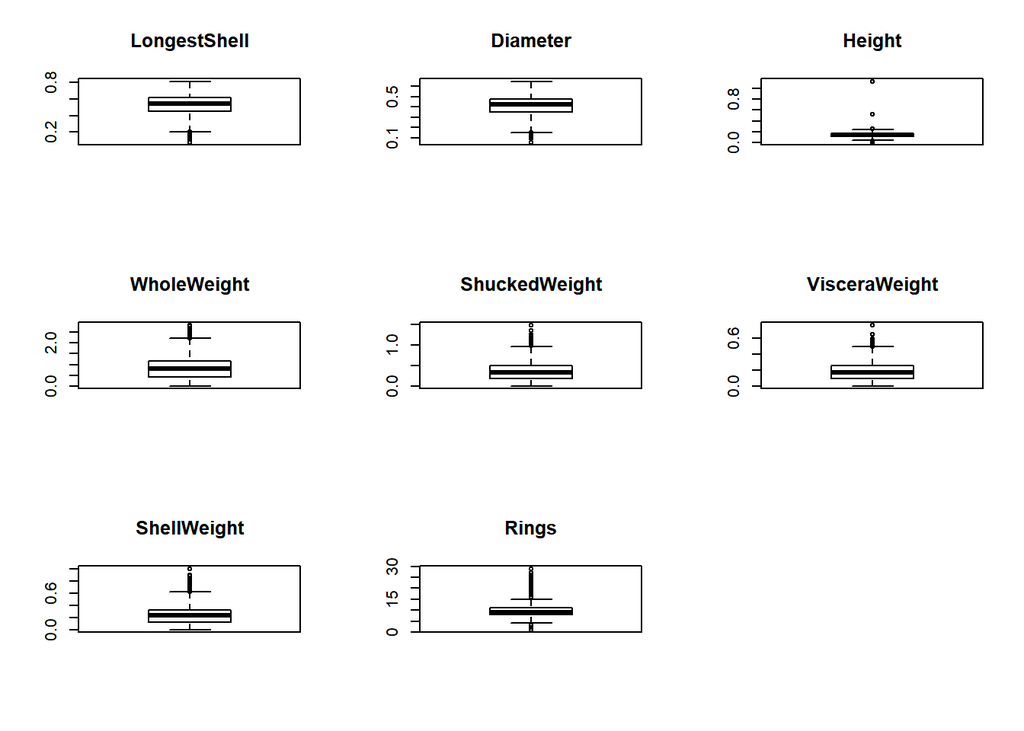

```r
# boxplots for each attribute
par(mfrow=c(3,3))
for(i in 2:9) {
    boxplot(dataset[,i], main=names(dataset)[i])
}
```

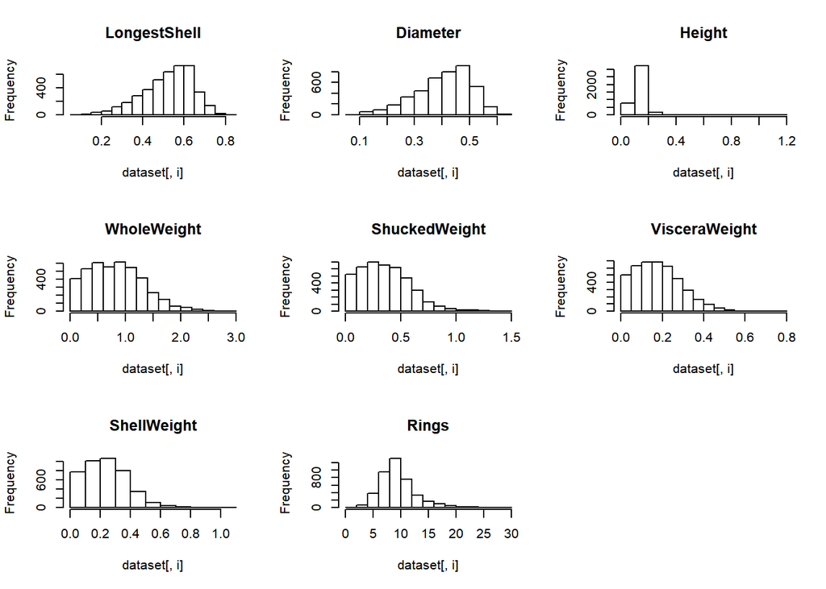

```r
# histograms each attribute
par(mfrow=c(3,3))
for(i in 2:9) {
    hist(dataset[,i], main=names(dataset)[i])
}
```

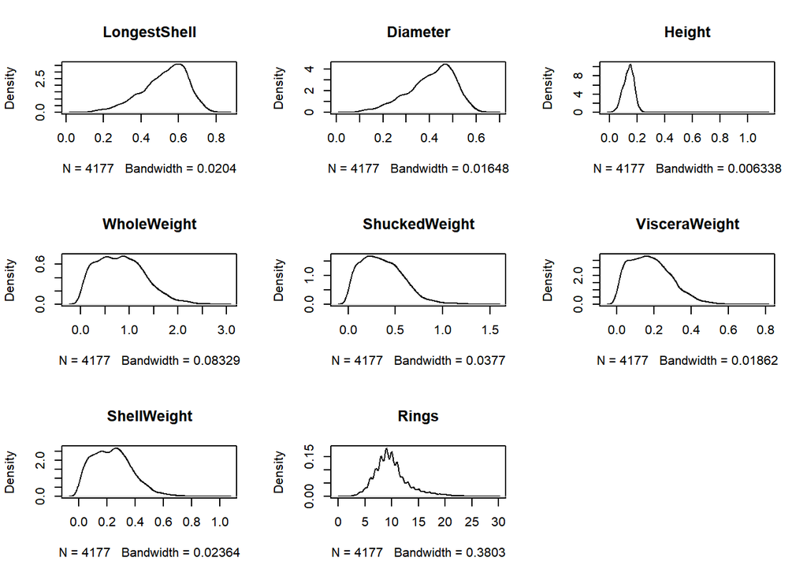

```r
# density plot for each attribute
par(mfrow=c(3,3))
for(i in 2:9) {
    plot(density(dataset[,i]), main=names(dataset)[i])
}
```

#### 2.b.ii) Multivariate plots to better understand the relationships between attributes

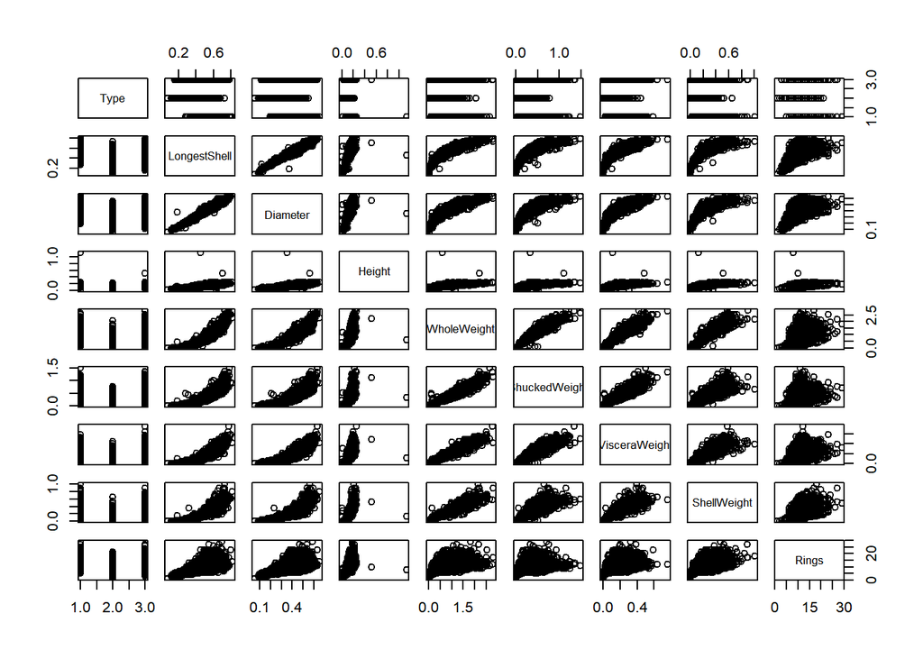

```r
# scatterplot matrix
pairs(dataset)
```

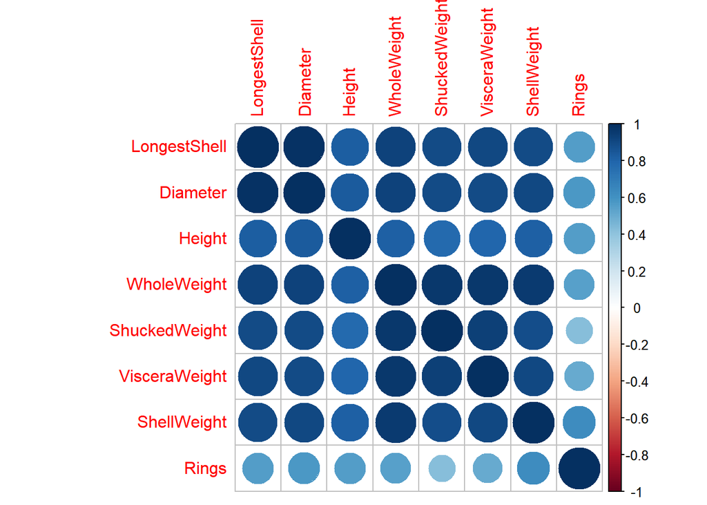

```r
# correlation plot
correlations <- cor(dataset[,2:9])
corrplot(correlations, method="circle")
```

## 3. Prepare Data

Some dataset may require additional preparation activities that will best exposes the structure of the problem and the relationships between the input attributes and the output variable. Some data-prep tasks might include:

- Cleaning data by removing duplicates, marking missing values and even imputing missing values.
- Feature selection where redundant features may be removed.
- Data transforms where attributes are scaled or redistributed in order to best expose the structure of the problem later to learning algorithms.

### 3.a) Data Cleaning

```r
# Not applicable for this iteration of the project.
```

### 3.b) Feature Selection

```r
# Not applicable for this iteration of the project.
```

### 3.c) Data Transforms

```r
# Not applicable for this iteration of the project.
```

## 4. Evaluate Algorithms - No Transformation

After the data-prep, we next work on finding a workable model by evaluating a subset of machine learning algorithms that are good at exploiting the structure of the dataset. The typical evaluation tasks include:

- Defining test options such as cross validation and the evaluation metric to use.
- Spot checking a suite of linear and nonlinear machine learning algorithms.
- Comparing the estimated accuracy of algorithms.

For this project, we will evaluate 5 different non-ensemble algorithms:

Linear Algorithms: Generalized Linear Model (GLM) and Linear Regression (LM)

Nonliear Algorithms: Classification and Regression Trees (CART), k-Nearest Neighbors (KNN), and Support Vector Machine (SVM)

The random number seed is reset before each run to ensure that the evaluation of each algorithm is performed using the same data splits. It ensures the results are directly comparable.

### 4.a) Test options and evaluation metric

```r
# Run algorithms using 10-fold cross validation
control <- trainControl(method="repeatedcv", number=10, repeats=3)
metric <- "RMSE"
seed <- 888
```

### 4.b) Generate Models using Algorithms

```r
# GLM
set.seed(seed)
fit.glm <- train(Rings~., data=dataset, method="glm", metric=metric, trControl=control)
# LM
set.seed(seed)
fit.lm <- train(Rings~., data=dataset, method="lm", metric=metric, trControl=control)
# SVM
set.seed(seed)
fit.svm <- train(Rings~., data=dataset, method="svmRadial", metric=metric, trControl=control)
# CART
set.seed(seed)
fit.cart <- train(Rings~., data=dataset, method="rpart", metric=metric, trControl=control)
# kNN
set.seed(seed)
fit.knn <- train(Rings~., data=dataset, method="knn", metric=metric, trControl=control)
```

### 4.c) Compare Algorithms

```r
results <- resamples(list(SVM=fit.svm, CART=fit.cart, kNN=fit.knn, GLM=fit.glm, LM=fit.lm))
summary(results)
```

```
##
## Call:
## summary.resamples(object = results)
##
## Models: SVM, CART, kNN, GLM, LM
## Number of resamples: 30
##
## MAE
##          Min.  1st Qu.   Median     Mean  3rd Qu.     Max. NA's
## SVM  1.334204 1.437936 1.460600 1.467028 1.501696 1.594782    0
## CART 1.752670 1.868024 1.925167 1.944488 2.030462 2.148017    0
## kNN  1.373541 1.474701 1.532682 1.525709 1.581652 1.631148    0
## GLM  1.405274 1.538347 1.580022 1.584984 1.630036 1.747117    0
## LM   1.405274 1.538347 1.580022 1.584984 1.630036 1.747117    0
##
## RMSE
##          Min.  1st Qu.   Median     Mean  3rd Qu.     Max. NA's
## SVM  1.866417 2.058851 2.161179 2.143445 2.215107 2.345532    0
## CART 2.311081 2.532638 2.607030 2.625545 2.725444 2.909041    0
## kNN  1.897629 2.133554 2.204303 2.190573 2.277420 2.374331    0
## GLM  1.968226 2.135908 2.227128 2.214150 2.279131 2.472869    0
## LM   1.968226 2.135908 2.227128 2.214150 2.279131 2.472869    0
##
## Rsquared
##           Min.   1st Qu.    Median      Mean   3rd Qu.      Max. NA's
## SVM  0.5247099 0.5493322 0.5731837 0.5708334 0.5907976 0.6291676    0
## CART 0.2611318 0.3080157 0.3267381 0.3371798 0.3675898 0.4354121    0
## kNN  0.4603405 0.5236911 0.5439546 0.5410710 0.5607916 0.6170636    0
## GLM  0.4651704 0.5122817 0.5328240 0.5303513 0.5523061 0.5984091    0
## LM   0.4651704 0.5122817 0.5328240 0.5303513 0.5523061 0.5984091    0
```

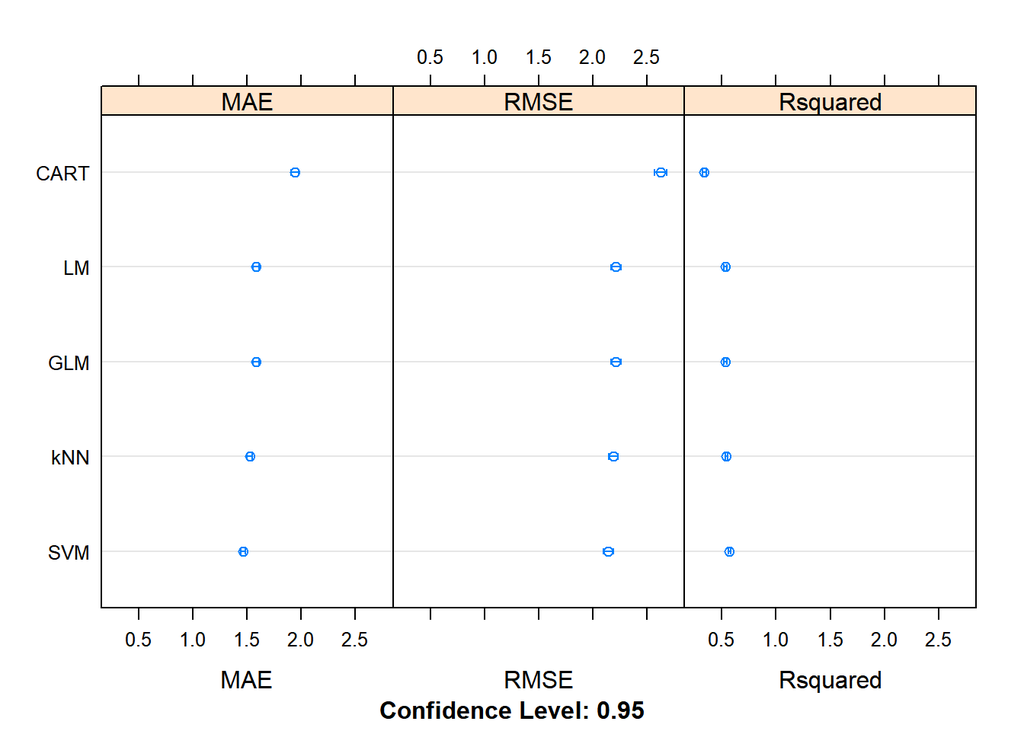

```r
dotplot(results)
```

## 5. Improve Accuracy

After we achieve a short list of machine learning algorithms with good level of accuracy, we can leverage ways to improve the accuracy of the models:

- Search for a combination of parameters for each algorithm using caret that yields the best results.
- Combine the prediction of multiple models into an ensemble prediction using standalone algorithms or the caretEnsemble package.

### 5.a) Algorithm Tuning

Finally, we will tune the best-performing algorithm further and see whether we can get more accuracy out of SVM.

```r
# SVM
set.seed(seed)
grid <- expand.grid(.sigma=c(0.01,0.025,0.05,0.075,0.1), .C=c(1))
fit.svm <- train(Rings~., data=dataset, method="svmRadial", metric=metric, tuneGrid=grid, trControl=control)
print(fit.svm)
```

```
## Support Vector Machines with Radial Basis Function Kernel
##
## 4177 samples
##    8 predictor
##
## No pre-processing
## Resampling: Cross-Validated (10 fold, repeated 3 times)
## Summary of sample sizes: 3759, 3760, 3760, 3759, 3760, 3759, ...
## Resampling results across tuning parameters:
##
##   sigma  RMSE      Rsquared   MAE
##   0.010  2.213622  0.5529550  1.512816
##   0.025  2.166432  0.5669829  1.484722
##   0.050  2.141948  0.5745767  1.467913
##   0.075  2.133257  0.5768338  1.461368
##   0.100  2.131183  0.5767182  1.460481
##
## Tuning parameter 'C' was held constant at a value of 1
## RMSE was used to select the optimal model using the smallest value.
## The final values used for the model were sigma = 0.1 and C = 1.
```

### 5.b) Ensembles

In this section, we will explore the use and tuning of ensemble algorithms to see whether we can improve the results. We will test the Bagged CART and Stochastic Gradient Boosting models.

```r
# Bagging
set.seed(seed)
fit.bagging <- train(Rings~., data=dataset, method="treebag", metric=metric, trControl=control)
# Gradient Boosting
set.seed(seed)
fit.boosting <- train(Rings~., data=dataset, method="gbm", metric=metric, trControl=control)
results <- resamples(list(SVM=fit.svm, BAG=fit.bagging, BOOST=fit.boosting))
summary(results)
```

```
##
## Call:
## summary.resamples(object = results)
##
## Models: SVM, BAG, BOOST
## Number of resamples: 30
##
## MAE
##           Min.  1st Qu.   Median     Mean  3rd Qu.     Max. NA's
## SVM   1.334646 1.423676 1.457626 1.460481 1.505495 1.594907    0
## BAG   1.479037 1.557925 1.621334 1.614970 1.668725 1.758843    0
## BOOST 1.413772 1.488461 1.514020 1.526828 1.573820 1.671408    0
##
## RMSE
##           Min.  1st Qu.   Median     Mean  3rd Qu.     Max. NA's
## SVM   1.855285 2.025120 2.149114 2.131183 2.204453 2.348310    0
## BAG   1.987886 2.161927 2.293874 2.265009 2.357384 2.487286    0
## BOOST 1.972288 2.064130 2.159176 2.164072 2.253411 2.381411    0
##
## Rsquared
##            Min.   1st Qu.    Median      Mean   3rd Qu.      Max. NA's
## SVM   0.5274160 0.5532161 0.5763113 0.5767182 0.5954707 0.6334970    0
## BAG   0.4476324 0.4803120 0.5092724 0.5098692 0.5371942 0.5858650    0
## BOOST 0.4928133 0.5257618 0.5524302 0.5501076 0.5788947 0.5968353    0
```

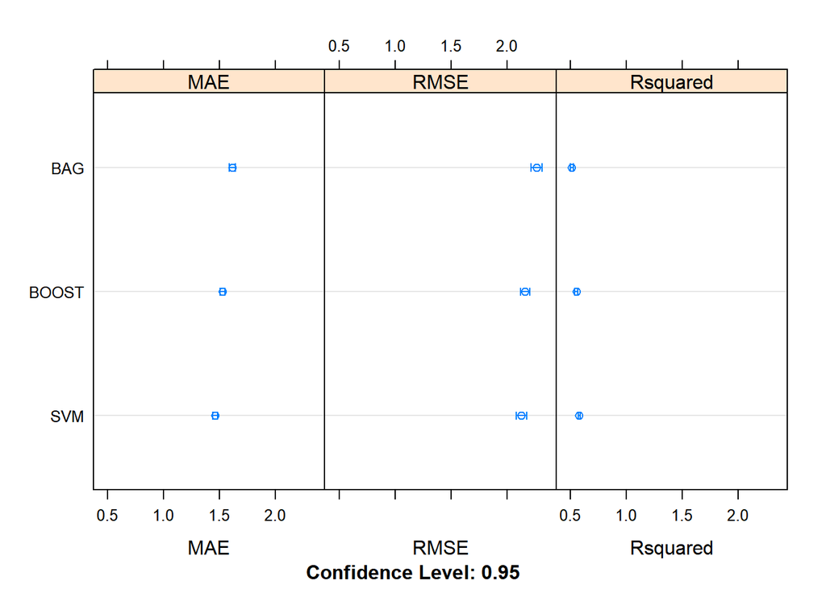

```r
dotplot(results)
```

## 6. Finalize Model

Once we have narrow down to a model that we believe can make accurate predictions on unseen data, we are ready to finalize it. Finalizing a model may involve sub-tasks such as:

- Using an optimal model tuned to make predictions on unseen data.
- Creating a standalone model using the tuned parameters
- Saving an optimal model to file for later use.

### 6.a) Predictions on validation dataset

```r
# Present Results
index <- best(fit.svm$results, metric, maximize=TRUE)
config <- fit.svm$results[index,]
print(config)
```

```
##   sigma C     RMSE Rsquared      MAE    RMSESD RsquaredSD      MAESD
## 1  0.01 1 2.213622 0.552955 1.512816 0.1319885 0.02918089 0.06578186
```

### 6.b) Create standalone model on entire training dataset

```r
# Not applicable for this iteration of the project.
```

### 6.c) Save model for later use

```r
# Not applicable for this iteration of the project.
```